# Lab 4: The Multi-Layer Perceptron

The goal of this project is to make a multi-layer perceptron while using the [US Census Demographic Data dataset](https://www.kaggle.com/datasets/muonneutrino/us-census-demographic-data/) to determine the child poverty rate for each county provided in the U.S.

## Load, Split, and Balance

```python
import pandas as pd
import numpy as np
import matplotlib.pyplot as plt
import os
from sklearn import preprocessing
from sklearn.model_selection import train_test_split
from sklearn.metrics import accuracy_score
import warnings
warnings.filterwarnings('ignore')
```

```
Mean and Median census tracts per county:
Median: 9.0
Mean: 37.21494370522006
```

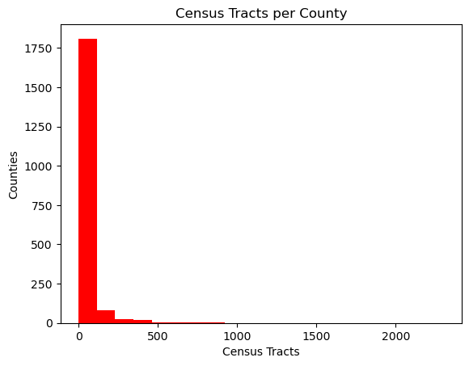

```python
import pandas as pd
import numpy as np
from sklearn import preprocessing
import matplotlib.pyplot as plt


df = pd.read_csv("censusDataset.csv")
df.dropna(inplace=True)
le = preprocessing.LabelEncoder()
df['State'] = le.fit_transform(df['State'])
df['County'] = le.fit_transform(df['County'])
counts = list(df["County"].groupby(df["County"]).count())


plt.hist(counts, bins=20, color='red')
plt.title("Census Tracts per County")
plt.xlabel("Census Tracts")
plt.ylabel("Counties")

median_count = np.median(counts)
mean_count = np.mean(counts)

print("Mean and Median census tracts per county: ")
print("Median: " + str(median_count))
print("Mean: " + str(mean_count))

plt.show()
```

Counties are a crucial component of the demographic data framework. They hold immense significance in the allocation of funding for poverty relief programs, much like states. The financial well-being of counties, largely dependent on property tax revenues, directly impacts the capacity to support poverty alleviation initiatives. The correlation between county-level resources and their role in supporting poverty relief programs underscores the substantial influence counties exert on the socio-economic landscape.

This interconnectedness becomes evident when we examine census tracts. Even when other demographic variables appear similar between two tracts, disparities in poverty levels often arise from variations in county funding. These disparities are frequently linked to geographical factors. Tracts located within wealthier counties tend to receive more resources, resulting in stronger support for poverty mitigation efforts. Conversely, tracts isolated from such financial advantages may experience lesser investment in essential programs aimed at uplifting and empowering those in need.

Therefore, the inclusion of counties as a prominent feature within the data ecosystem is not only relevant but imperative. It provides valuable insights into the dynamics of poverty relief funding, contributing to a comprehensive understanding of the intricate tapestry of social well-being and economic disparities.

### Visualizing Child Poverty Rates

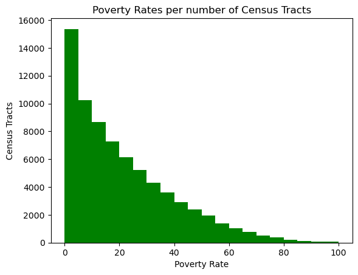

```python
plt.hist(df["ChildPoverty"], bins = 20, color = 'green')
plt.title("Poverty Rates per number of Census Tracts")
plt.xlabel("Poverty Rate")
plt.ylabel("Census Tracts")
```

The graph above shows that child poverty rates among census tracts exhibit a non-uniform distribution. The data displays a prominent mode near zero, with the number of census tracts experiencing higher rates gradually decreasing from there. Since the data is unimodal, it lacks distinct breakpoints for categorizing Child Poverty Rates directly. Consequently, we've chosen to divide the data into classes, each containing an equal number of census tracts. This approach enables us to utilize the entire dataset for training and testing, eliminating the need to discard data in order to maintain class balance.

```python
classes = pd.qcut(df['ChildPoverty'], 4, labels = [0,1,2,3])
df['ChildPoverty'] = classes

df.drop('TractId', axis = 1, inplace = True)

X_train, X_test, y_train, y_test = train_test_split(df.drop('ChildPoverty', axis = 1), df['ChildPoverty'], test_size = 0.2, stratify = df['ChildPoverty'])

X_train = np.array(X_train)
y_train = np.array(y_train)
X_test = np.array(X_test)
y_test = np.array(y_test)
```

## Pre-processing and Initial Modeling

```python
# Example adapted from https://github.com/rasbt/python-machine-learning-book/blob/master/code/ch12/ch12.ipynb
# Original Author: Sebastian Raschka

import numpy as np
from scipy.special import expit
import pandas as pd
import sys

# start with a simple base classifier, which can't be fit or predicted
# it only has internal classes to be used by classes that will subclass it
class TwoLayerPerceptronBase(object):
    def __init__(self, n_hidden=30,
                 C=0.0, epochs=500, eta=0.001, random_state=None,
                 alpha=0.0, decrease_const=0.0, shuffle=True,
                 minibatches=1):
        np.random.seed(random_state)
        self.n_hidden = n_hidden
        self.l2_C = C
        self.epochs = epochs
        self.eta = eta
        # Mini Batch params:
        self.alpha = alpha
        self.decrease_const = decrease_const
        self.shuffle = shuffle
        self.minibatches = minibatches


    @staticmethod
    def _encode_labels(y):
        """Encode labels into one-hot representation"""
        onehot = pd.get_dummies(y).values.T

        return onehot

    def _initialize_weights(self):
        """Initialize weights Glorot and He normalization."""
        init_bound = 4*np.sqrt(6. / (self.n_hidden + self.n_features_))
        W1 = np.random.uniform(-init_bound, init_bound,(self.n_hidden, self.n_features_))

        # reduce the final layer magnitude in order to balance the size of the gradients
        # between
        init_bound = 4*np.sqrt(6 / (self.n_output_ + self.n_hidden))
        W2 = np.random.uniform(-init_bound, init_bound,(self.n_output_, self.n_hidden))

        b1 = np.zeros((self.n_hidden, 1))
        b2 = np.zeros((self.n_output_, 1))

        return W1, W2, b1, b2

    @staticmethod
    def _sigmoid(z):
        """Use scipy.special.expit to avoid overflow"""
        # 1.0 / (1.0 + np.exp(-z))
        return expit(z)


    @staticmethod
    def _L2_reg(lambda_, W1, W2):
        """Compute L2-regularization cost"""
        # only compute for non-bias terms
        return (lambda_/2.0) * np.sqrt(np.mean(W1[:, 1:] ** 2) + np.mean(W2[:, 1:] ** 2))

    def _cost(self,A3,Y_enc,W1,W2):
        '''Get the objective function value'''
        cost = -np.mean(np.nan_to_num((Y_enc*np.log(A3)+(1-Y_enc)*np.log(1-A3))))
        L2_term = self._L2_reg(self.l2_C, W1, W2)
        return cost + L2_term

    def _feedforward(self, X, W1, W2, b1, b2):
        """Compute feedforward step
        -----------
        X : Input layer with original features.
        W1: Weight matrix for input layer -> hidden layer.
        W2: Weight matrix for hidden layer -> output layer.
        ----------
        a1-a3 : activations into layer (or output layer)
        z1-z2 : layer inputs

        """
        A1 = X.T
        Z1 = W1 @ A1 + b1
        A2 = self._sigmoid(Z1)
        Z2 = W2 @ A2 + b2
        A3 = self._sigmoid(Z2)
        return A1, Z1, A2, Z2, A3

    def _get_gradient(self, A1, A2, A3, Z1, Z2, Y_enc, W1, W2):
        """ Compute gradient step using backpropagation.
        """
        # vectorized backpropagation
        V2 = (A3-Y_enc) # <- this is only line that changed
        V1 = A2*(1-A2)*(W2.T @ V2)

        gradW2 = V2 @ A2.T
        gradW1 = V1 @ A1.T

        gradb2 = np.sum(V2, axis=1).reshape((-1,1))
        gradb1 = np.sum(V1, axis=1).reshape((-1,1))

        # regularize weights that are not bias terms
        gradW1 += W1 * self.l2_C
        gradW2 += W2 * self.l2_C

        return gradW1, gradW2, gradb1, gradb2

    def predict(self, X):
        """Predict class labels"""
        _, _, _, _, A3 = self._feedforward(X, self.W1, self.W2, self.b1, self.b2)
        y_pred = np.argmax(A3, axis=0)
        return y_pred
    def fit(self, X, y, print_progress=False, XY_test=None):
        """ Learn weights from training data. With mini-batch"""
        X_data, y_data = X.copy(), y.copy()
        Y_enc = self._encode_labels(y)

        # init weights and setup matrices
        self.n_features_ = X_data.shape[1]
        self.n_output_ = Y_enc.shape[0]
        self.W1, self.W2, self.b1, self.b2 = self._initialize_weights()

        # start momentum at zero for previous updates
        rho_W1_prev = np.zeros(self.W1.shape) # for momentum
        rho_W2_prev = np.zeros(self.W2.shape) # for momentum

        self.cost_ = []
        self.score_ = []
        # get starting acc
        self.score_.append(accuracy_score(y_data,self.predict(X_data)))
        # keep track of validation, if given
        if XY_test is not None:
            X_test = XY_test[0].copy()
            y_test = XY_test[1].copy()
            self.val_score_ = []
            self.val_score_.append(accuracy_score(y_test,self.predict(X_test)))

        for i in range(self.epochs):

            # adaptive learning rate
            # \frac{\eta}{1+\epsilon\cdot k}
            eta = self.eta / (1 + self.decrease_const*i)

            if print_progress>0 and (i+1)%print_progress==0:
                sys.stderr.write('\rEpoch: %d/%d' % (i+1, self.epochs))
                sys.stderr.flush()

            if self.shuffle:
                idx_shuffle = np.random.permutation(y_data.shape[0])
                X_data, Y_enc, y_data = X_data[idx_shuffle], Y_enc[:, idx_shuffle], y_data[idx_shuffle]

            mini = np.array_split(range(y_data.shape[0]), self.minibatches)
            mini_cost = []
            for idx in mini:
                # feedforward
                A1, Z1, A2, Z2, A3 = self._feedforward(X_data[idx],
                                                       self.W1,
                                                       self.W2,
                                                       self.b1,
                                                       self.b2
                                                      )

                cost = self._cost(A3,Y_enc[:, idx],self.W1,self.W2)
                mini_cost.append(cost) # this appends cost of mini-batch only

                # compute gradient via backpropagation
                gradW1, gradW2, gradb1, gradb2 = self._get_gradient(A1=A1, A2=A2, A3=A3, Z1=Z1, Z2=Z2,
                                                  Y_enc=Y_enc[:, idx],
                                                  W1=self.W1,W2=self.W2)

                # momentum calculations
                rho_W1, rho_W2 = eta * gradW1, eta * gradW2
                self.W1 -= (rho_W1 + (self.alpha * rho_W1_prev)) # update with momentum
                self.W2 -= (rho_W2 + (self.alpha * rho_W2_prev)) # update with momentum
                self.b1 -= eta * gradb1
                self.b2 -= eta * gradb2
                rho_W1_prev, rho_W2_prev = rho_W1, rho_W2


            self.cost_.append(mini_cost)
            self.score_.append(accuracy_score(y_data,self.predict(X_data)))
            if XY_test is not None:
                self.val_score_.append(accuracy_score(y_test,self.predict(X_test)))

        return self
```

```python
hyper_params = {'n_hidden': 30,
            'C': 0.1, 'epochs': 100, 'eta': 0.001,
            'alpha': 0.001, 'decrease_const': 1e-5, 'minibatches': 50,
            'shuffle': True, 'random_state': 1}
model1 = TwoLayerPerceptronBase(**hyper_params)
model1.fit(X_train,y_train,print_progress=1,XY_test=(X_test,y_test))
```

```
Epoch: 100/100
```

```
<__main__.TwoLayerPerceptronBase at 0x16a4afdd0>
```

```
Accuracy: 24.99%
Counts of Predicted Classes:
3    14544
dtype: int64
```

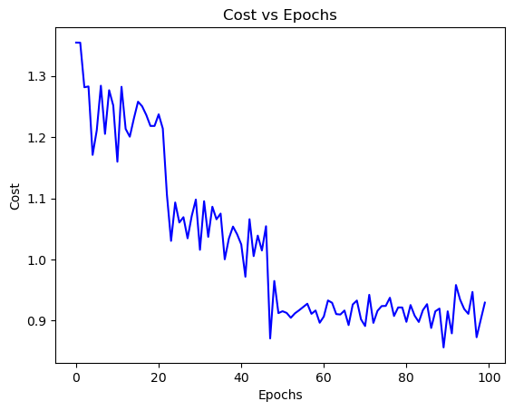

```python
y_pred = model1.predict(X_test)
print('Accuracy: %.2f%%' % (accuracy_score(y_test, y_pred)*100))
# print out the value counts of each item in y_pred:
print("Counts of Predicted Classes: ")
print(pd.Series(y_pred).value_counts())
cost_avgs = np.mean(model1.cost_,axis=1)
plt.plot(range(len(cost_avgs)), cost_avgs, color='blue')
plt.ylabel('Cost')
plt.xlabel('Epochs')
plt.title('Cost vs Epochs')
plt.show()
```

```python
from sklearn.preprocessing import StandardScaler
scaler = StandardScaler()
X_train_scl = X_train.copy()
X_test_scl = X_test.copy()

X_train_scl[:,2:] = scaler.fit_transform(X_train[:,2:])
X_test_scl[:,2:] = scaler.fit_transform(X_test[:,2:])

model2 = TwoLayerPerceptronBase(**hyper_params)
model2.fit(X_train_scl,y_train,print_progress=1,XY_test=(X_test_scl,y_test))
```

```
Epoch: 100/100
```

```
<__main__.TwoLayerPerceptronBase at 0x16a5570d0>
```

```
Accuracy: 24.94%
Counts of Predicted Classes:
2    14477
0       67
dtype: int64
```

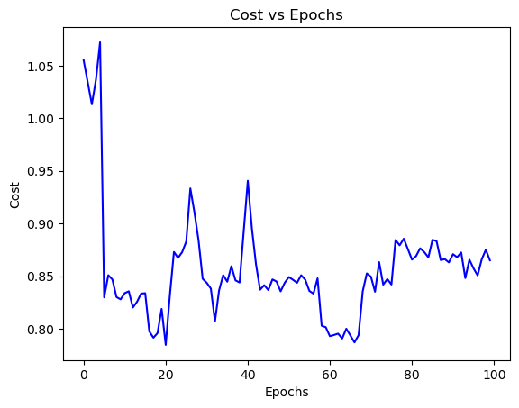

```python
y_pred_scl = model2.predict(X_test_scl)
print('Accuracy: %.2f%%' % (accuracy_score(y_test, y_pred_scl)*100))
print("Counts of Predicted Classes: ")
print(pd.Series(y_pred_scl).value_counts())
cost_avgs = np.mean(model2.cost_,axis=1)
plt.plot(range(len(cost_avgs)), cost_avgs, color='blue')
plt.ylabel('Cost')
plt.xlabel('Epochs')
plt.title('Cost vs Epochs')
plt.show()
```

The persistent concern centers on whether these large label-encoded values, particularly in the "county" feature, are introducing complexities that hinder the network's learning process. To address this, we are now considering the implementation of one-hot encoding for the categorical variables. This modification aims to investigate whether transforming the categorical data in this manner can yield more favorable results and alleviate the optimization challenges encountered thus far.

```python
scaler = preprocessing.StandardScaler().fit(X_train[:,2:])

X_train_scl = X_train.copy()
X_test_scl = X_test.copy()
X_train_scl[:,2:] = scaler.transform(X_train[:,2:])
X_test_scl[:,2:] = scaler.transform(X_test[:,2:])

X_train_one_hot = X_train_scl[:,:2]
X_test_one_hot = X_test_scl[:,:2]

X_one_hot = np.concatenate((X_train_one_hot,X_test_one_hot),axis=0)

# Begin one hot encoding
enc = preprocessing.OneHotEncoder()
enc.fit(X_one_hot)
X_train_one_hot = enc.transform(X_train_one_hot).toarray()
X_test_one_hot = enc.transform(X_test_one_hot).toarray()

X_train_scl_one_hot = np.concatenate((X_train_one_hot,X_train_scl[:,2:]),axis=1)
X_test_scl_one_hot = np.concatenate((X_test_one_hot,X_test_scl[:,2:]),axis=1)

model3 = TwoLayerPerceptronBase(**hyper_params)
model3.fit(X_train_scl_one_hot,y_train,print_progress=1,XY_test=(X_test_scl_one_hot,y_test))
```

```
Epoch: 100/100
```

```
<__main__.TwoLayerPerceptronBase at 0x16a546150>
```

```
Accuracy: 74.02%
Counts of Predicted Classes:
2    4017
3    3621
0    3605
1    3301
dtype: int64
```

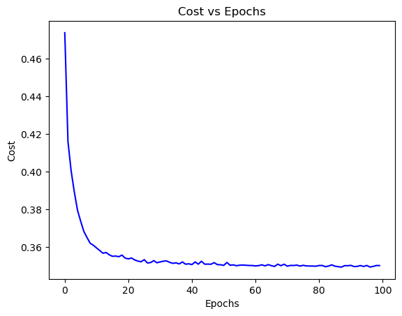

```python
y_pred_scl_one_hot = model3.predict(X_test_scl_one_hot)
print('Accuracy: %.2f%%' % (accuracy_score(y_test, y_pred_scl_one_hot)*100))
print("Counts of Predicted Classes: ")
print(pd.Series(y_pred_scl_one_hot).value_counts())
cost_avgs = np.mean(model3.cost_,axis=1)
plt.plot(range(len(cost_avgs)), cost_avgs, color='blue')
plt.ylabel('Cost')
plt.xlabel('Epochs')
plt.title('Cost vs Epochs')
plt.show()
```

The introduction of one-hot encoding and feature scaling represents a significant breakthrough in the network's performance. This transformation is clearly depicted in the convergence of the loss function, as illustrated in the graph, and the marked increase in accuracy. It's a substantial improvement, far surpassing random chance—a notable contrast to previous network iterations.

Our working hypothesis is that this success can be attributed to the synergistic effects of both scaling and one-hot encoding. Together, they serve to maintain the features within manageable ranges, preventing the network from inadvertently learning erroneous ordinal patterns in the categorical data. For instance, encoding a state with a higher numerical value doesn't imply any greater significance in reality.

However, we believe that the paramount contributing factor is the imposition of constrained dynamic ranges on all variables. This constraint effectively curtails biases among variables, enabling the Glorot initialization to function optimally. Consequently, activations do not prematurely saturate, a factor known to destabilize the Cross-Entropy loss and gradients, which had been a source of instability in previous iterations.